# Introduction

In this assignment, we are to explore customer departures from a business, based on customers' given attributes.  
In the competitive telecommunications industry, customer churn is a significant concern as retaining customers is often more cost-effective than acquiring new ones. Churn happens when customers discontinue their services. The most prominent factors that influence this decision are quality, pricing, customer support, and the availablility of alternative services.  
Our aim is to enable companies to pinpoint potential churners using available data.

Variable Description:  
cust_id: Unique identifier for each customer.  
region: Geographical region where the customer is located.  
tenure: Number of months the customer has been with the company.  
age: Age of customer  
marital: Marital status of the customer.  
address: Address of customer  
income: Yearly income (in thousands)  
ed: Education level  
employ: Number of years customer has been employed.  
retire: Retirement status  
gender: Gender of the customer.  
reside: Length of time at current address.  
tollfree: Whether customer has toll-free number.  
equip: Whether customer has equipment.  
callcard: Whether customer has calling card.  
wireless: Whether the customer has wireless service.  
longmon: Monthly long-distance call usage.  
tollmon: Monthly toll-free call usage.  
equipmon: Monthly equipment usage.  
cardmon: Monthly call card usage.  
wiremon: Monthly wireless usage.  
longten: Long distance call tenure total.  
tollten: Toll-free call tenure total.  
equipten: Equipement usage total tenure.  
cardten: Calling card usage total tenure.  
wireten: Wireless usage total tenure.  
multline: Whether customer has multiple lines.  
voice: Whether customer uses voice services.  
pager: Whether customer uses pager services.  
internet: Whether customer uses internet services.  
callid: Whether customer uses caller id.  
callwait: Whether customer uses call waiting.  
forward: Whether customer uses call forwarding.  
confer: Whether customer uses conference calls.  
ebill: Whether customer uses electronic billing.  
loglong: Logarithmic transformation of long-distance call usage.  
lninc: Logarithmic transformation of income.  
custcat: Customer category.  
churn: Target variable representing churn.

# Data Understanding and Preprocessing

During this section I examined the dataset for any missing values, ensuring data completeness and integrity. I transformed all categorical variables stored as 'object' data types into 'category' types. I created a variety of visualizations to explore the relationships between churn and key variables.

```python
# Mounting google drive
from google.colab import drive
drive.mount('/content/drive')
```

```python
# importing libraries
import pandas as pd
import seaborn as sns
from sklearn.model_selection import train_test_split
from matplotlib import pyplot as plt
from sklearn import tree
from sklearn.tree import DecisionTreeClassifier
from sklearn.metrics import confusion_matrix
from sklearn.metrics import ConfusionMatrixDisplay
from sklearn.metrics import classification_report
```

```python
churn_data = pd.read_csv("/content/drive/MyDrive/IS470_data/CutomerChurnData.csv")
churn_data
```

|  | cust_id | region | tenure | age | marital | address | income | ed | employ | retire | ... | internet | callid | callwait | forward | confer | ebill | loglong | lninc | custcat | churn |
| --- | --- | --- | --- | --- | --- | --- | --- | --- | --- | --- | --- | --- | --- | --- | --- | --- | --- | --- | --- | --- | --- |
| 0 | C00124 | R2 | 13 | 44 | Y | 9 | 64 | E4 | 5 | N | ... | N | N | N | Y | N | N | 1.308 | 4.159 | C1 | Y |
| 1 | C00125 | R3 | 68 | 52 | Y | 24 | 116 | E1 | 29 | N | ... | N | Y | Y | N | Y | N | 2.899 | 4.754 | C3 | N |
| 2 | C00126 | R2 | 23 | 30 | Y | 9 | 30 | E1 | 2 | N | ... | N | Y | N | Y | Y | N | 1.841 | 3.401 | C3 | N |
| 3 | C00127 | R3 | 45 | 22 | Y | 2 | 19 | E2 | 4 | N | ... | Y | N | Y | N | N | Y | 2.389 | 2.944 | C2 | Y |
| 4 | C00128 | R3 | 45 | 59 | Y | 7 | 166 | E4 | 31 | N | ... | N | Y | Y | Y | Y | N | 2.277 | 5.112 | C3 | N |
| ... | ... | ... | ... | ... | ... | ... | ... | ... | ... | ... | ... | ... | ... | ... | ... | ... | ... | ... | ... | ... | ... |
| 995 | C01119 | R1 | 50 | 43 | N | 6 | 27 | E3 | 4 | N | ... | N | Y | Y | Y | Y | N | 2.708 | 3.296 | C3 | N |
| 996 | C01120 | R1 | 34 | 52 | Y | 2 | 106 | E2 | 19 | N | ... | Y | Y | N | Y | Y | N | 1.599 | 4.663 | C3 | N |
| 997 | C01121 | R1 | 15 | 46 | Y | 17 | 63 | E5 | 1 | N | ... | Y | Y | N | Y | Y | Y | 1.308 | 4.143 | C4 | Y |
| 998 | C01122 | R1 | 7 | 34 | N | 2 | 22 | E5 | 5 | N | ... | N | N | N | N | N | N | 1.537 | 3.091 | C1 | N |
| 999 | C01123 | R3 | 70 | 49 | N | 18 | 87 | E2 | 22 | N | ... | N | Y | Y | Y | Y | N | 3.243 | 4.466 | C3 | N |

1000 rows × 39 columns

```python
#visualizing columns
churn_data.keys()
```

```
Index(['cust_id', 'region', 'tenure', 'age', 'marital', 'address', 'income',
       'ed', 'employ', 'retire', 'gender', 'reside', 'tollfree', 'equip',
       'callcard', 'wireless', 'longmon', 'tollmon', 'equipmon', 'cardmon',
       'wiremon', 'longten', 'tollten', 'equipten', 'cardten', 'wireten',
       'multline', 'voice', 'pager', 'internet', 'callid', 'callwait',
       'forward', 'confer', 'ebill', 'loglong', 'lninc', 'custcat', 'churn'],
      dtype='object')
```

```python
pd.set_option('display.max_columns', None) #To display all columns
```

```python
churn_data.head()
```

|  | cust_id | region | tenure | age | marital | address | income | ed | employ | retire | gender | reside | tollfree | equip | callcard | wireless | longmon | tollmon | equipmon | cardmon | wiremon | longten | tollten | equipten | cardten | wireten | multline | voice | pager | … |
| --- | --- | --- | --- | --- | --- | --- | --- | --- | --- | --- | --- | --- | --- | --- | --- | --- | --- | --- | --- | --- | --- | --- | --- | --- | --- | --- | --- | --- | --- | --- |
| 0 | C00124 | R2 | 13 | 44 | Y | 9 | 64 | E4 | 5 | N | N | 2 | N | N | Y | N | 3.70 | 0.0 | 0.0 | 7.50 | 0.0 | 37.45 | 0.00 | 0.0 | 110 | 0.0 | N | N | N | … |
| 1 | C00125 | R3 | 68 | 52 | Y | 24 | 116 | E1 | 29 | N | Y | 2 | Y | N | Y | N | 18.15 | 18.0 | 0.0 | 30.25 | 0.0 | 1300.60 | 1247.20 | 0.0 | 2150 | 0.0 | N | N | N | … |
| 2 | C00126 | R2 | 23 | 30 | Y | 9 | 30 | E1 | 2 | N | N | 4 | N | N | N | N | 6.30 | 0.0 | 0.0 | 0.00 | 0.0 | 157.05 | 0.00 | 0.0 | 0 | 0.0 | N | N | N | … |
| 3 | C00127 | R3 | 45 | 22 | Y | 2 | 19 | E2 | 4 | N | Y | 5 | N | N | Y | N | 10.90 | 0.0 | 0.0 | 8.75 | 0.0 | 504.50 | 0.00 | 0.0 | 415 | 0.0 | Y | N | N | … |
| 4 | C00128 | R3 | 45 | 59 | Y | 7 | 166 | E4 | 31 | N | N | 5 | Y | N | Y | N | 9.75 | 28.5 | 0.0 | 12.00 | 0.0 | 449.05 | 1240.15 | 0.0 | 505 | 0.0 | Y | N | N | … |

```python
churn_data.isnull().sum()
```

|  | 0 |
| --- | --- |
| cust_id | 0 |
| region | 0 |
| tenure | 0 |
| age | 0 |
| marital | 0 |
| address | 0 |
| income | 0 |
| ed | 0 |
| employ | 0 |
| retire | 0 |
| gender | 0 |
| reside | 0 |
| tollfree | 0 |
| equip | 0 |
| callcard | 0 |
| wireless | 0 |
| longmon | 0 |
| tollmon | 0 |
| equipmon | 0 |
| cardmon | 0 |
| wiremon | 0 |
| longten | 0 |
| tollten | 0 |
| equipten | 0 |
| cardten | 0 |
| wireten | 0 |
| multline | 0 |
| voice | 0 |
| pager | 0 |
| internet | 0 |
| callid | 0 |
| callwait | 0 |
| forward | 0 |
| confer | 0 |
| ebill | 0 |
| loglong | 0 |
| lninc | 0 |
| custcat | 0 |
| churn | 0 |

**dtype:** int64

```python
churn_data.dtypes
```

|  | 0 |
| --- | --- |
| cust_id | object |
| region | object |
| tenure | int64 |
| age | int64 |
| marital | object |
| address | int64 |
| income | int64 |
| ed | object |
| employ | int64 |
| retire | object |
| gender | object |
| reside | int64 |
| tollfree | object |
| equip | object |
| callcard | object |
| wireless | object |
| longmon | float64 |
| tollmon | float64 |
| equipmon | float64 |
| cardmon | float64 |
| wiremon | float64 |
| longten | float64 |
| tollten | float64 |
| equipten | float64 |
| cardten | int64 |
| wireten | float64 |
| multline | object |
| voice | object |
| pager | object |
| internet | object |
| callid | object |
| callwait | object |
| forward | object |
| confer | object |
| ebill | object |
| loglong | float64 |
| lninc | float64 |
| custcat | object |
| churn | object |

**dtype:** object

```python
churn_data['cust_id'] = churn_data['cust_id'].astype('category')
churn_data['region'] = churn_data['region'].astype('category')
churn_data['marital'] = churn_data['marital'].astype('category')
churn_data['address'] = churn_data['address'].astype('category')
churn_data['retire'] = churn_data['retire'].astype('category')
churn_data['gender'] = churn_data['gender'].astype('category')
churn_data['tollfree'] = churn_data['tollfree'].astype('category')
churn_data['equip'] = churn_data['equip'].astype('category')
churn_data['wireless'] = churn_data['wireless'].astype('category')
churn_data['multline'] = churn_data['multline'].astype('category')
churn_data['voice'] = churn_data['voice'].astype('category')
churn_data['pager'] = churn_data['pager'].astype('category')
churn_data['internet'] = churn_data['internet'].astype('category')
churn_data['callcard'] = churn_data['callcard'].astype('category')
churn_data['callid'] = churn_data['callid'].astype('category')
churn_data['callwait'] = churn_data['callwait'].astype('category')
churn_data['forward'] = churn_data['forward'].astype('category')
churn_data['confer'] = churn_data['confer'].astype('category')
churn_data['ebill'] = churn_data['ebill'].astype('category')
churn_data['custcat'] = churn_data['custcat'].astype('category')
churn_data['churn'] = churn_data['churn'].astype('category')
churn_data['ed'] = churn_data['ed'].astype('category')
```

```python
churn_data.dtypes
```

|  | 0 |
| --- | --- |
| cust_id | category |
| region | category |
| tenure | int64 |
| age | int64 |
| marital | category |
| address | category |
| income | int64 |
| ed | category |
| employ | int64 |
| retire | category |
| gender | category |
| reside | int64 |
| tollfree | category |
| equip | category |
| callcard | category |
| wireless | category |
| longmon | float64 |
| tollmon | float64 |
| equipmon | float64 |
| cardmon | float64 |
| wiremon | float64 |
| longten | float64 |
| tollten | float64 |
| equipten | float64 |
| cardten | int64 |
| wireten | float64 |
| multline | category |
| voice | category |
| pager | category |
| internet | category |
| callid | category |
| callwait | category |
| forward | category |
| confer | category |
| ebill | category |
| loglong | float64 |
| lninc | float64 |
| custcat | category |
| churn | category |

**dtype:** object

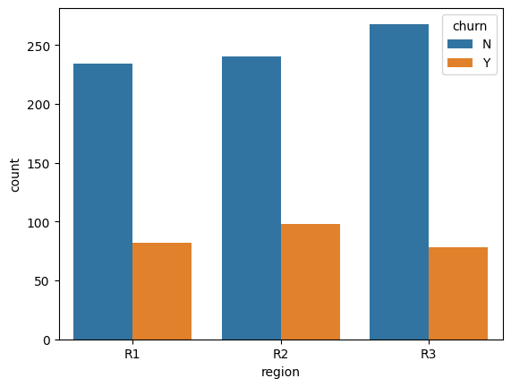

```python
# This is to analyze if churn varies by region
sns.countplot(x='region', hue='churn', data=churn_data)
```

Analyzing the above graph we can clearly see that R3 has our more loyal customers and R2 has the customers that have churned and stopped using our service.

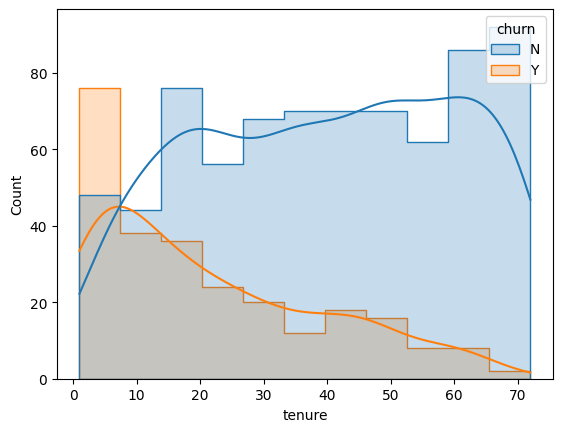

```python
# This shows me how long customers who churned stayed with the company compared to those who didn’t.
sns.histplot(data=churn_data, x='tenure', hue='churn', kde=True, element='step')
```

By analyzing the above graph we can see that the longer a customer stays and uses our services, the lower the chance of them churning. The cross section of this graph will help a lot when constructing the model since we can use this as one of our more precise guideliness for yes/no churn. The exact tenure seems to be around 8 months of use of when customers tend to stay and not cancel services.

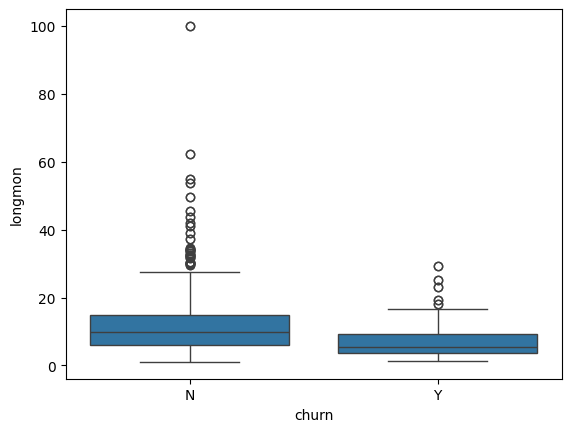

```python
# This will show me the difference in monthly usage between people who stayed/left.
sns.boxplot(x='churn', y='longmon', data=churn_data)
```

The above graph shows us that the customers with 10 long distance montly usage and above have a higher chance of not churning compared to customers with less than 10 long distance usage. This indicates that customers tend to stay when they have a consistant long distance usage.

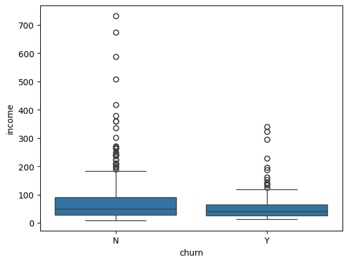

```python
# This analyzes if customer income affects churn
sns.boxplot(x='churn', y='income', data=churn_data)
```

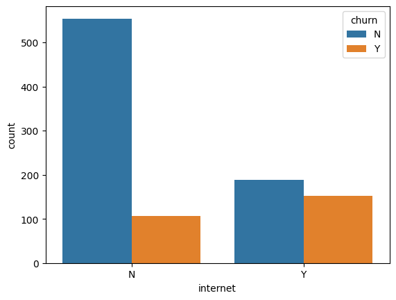

```python
# This analyzes if internet service affects churn
sns.countplot(x='internet', hue='churn', data=churn_data)
```

Analyzing the above graph we see with a suprise that people who did not have our internet service stayed with the company at higher rates versus people who did have our internet service. This could mean a plethora of things starting with our internet service having some serious issues which might affect churn.

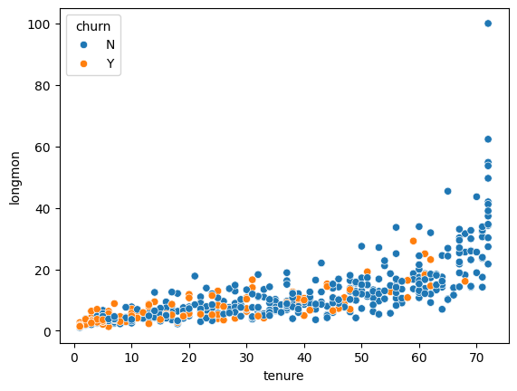

```python
# Explores the relationship between usage/tenure and how it affects churn
sns.scatterplot(x='tenure', y='longmon', hue='churn', data=churn_data)
```

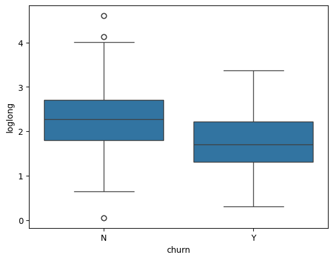

```python
# This analyzes impact of long distance usage on churn
sns.boxplot(x='churn', y='loglong', data=churn_data)
```

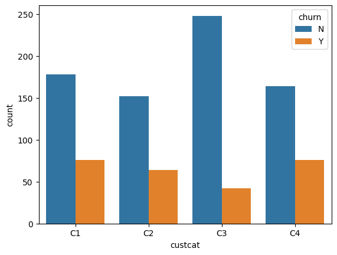

```python
#This shows different customer categories and churn
sns.countplot(x='custcat', hue='churn', data=churn_data)
```

In analyzing the above graph we can clearly see that our most loyal customer is C3 customers. The customers who have churned are mostly part of C1 and C4 groups.

```python
churn_data.select_dtypes(include = ['number']).corr()
```

|  | tenure | age | income | employ | reside | longmon | tollmon | equipmon | cardmon | wiremon | longten | tollten | equipten | cardten | wireten | loglong | lninc |
| --- | --- | --- | --- | --- | --- | --- | --- | --- | --- | --- | --- | --- | --- | --- | --- | --- | --- |
| tenure | 1.000000 | 0.475715 | 0.260311 | 0.520837 | 0.003392 | 0.707012 | 0.183964 | -0.060533 | 0.464380 | 0.122197 | 0.743025 | 0.465131 | 0.305777 | 0.671865 | 0.318131 | 0.834781 | 0.317191 |
| age | 0.475715 | 1.000000 | 0.375201 | 0.667698 | -0.219699 | 0.399567 | 0.108035 | -0.087599 | 0.357184 | 0.035937 | 0.423347 | 0.255622 | 0.057875 | 0.429788 | 0.102269 | 0.423413 | 0.408809 |
| income | 0.260311 | 0.375201 | 1.000000 | 0.611087 | -0.099252 | 0.216594 | 0.169940 | -0.035326 | 0.176103 | 0.098222 | 0.232504 | 0.249691 | 0.012987 | 0.203118 | 0.123740 | 0.225944 | 0.850498 |
| employ | 0.520837 | 0.667698 | 0.611087 | 1.000000 | -0.104103 | 0.457547 | 0.189690 | -0.159914 | 0.344947 | 0.017875 | 0.489562 | 0.342825 | -0.001937 | 0.443235 | 0.099254 | 0.456350 | 0.668575 |
| reside | 0.003392 | -0.219699 | -0.099252 | -0.104103 | 1.000000 | -0.008030 | 0.076684 | -0.009835 | 0.020076 | 0.048737 | -0.011136 | 0.018758 | 0.009561 | 0.005268 | 0.038325 | -0.003076 | -0.113496 |
| longmon | 0.707012 | 0.399567 | 0.216594 | 0.457547 | -0.008030 | 1.000000 | 0.132686 | -0.043699 | 0.465429 | 0.070288 | 0.980346 | 0.345019 | 0.202495 | 0.648830 | 0.216786 | 0.871126 | 0.250000 |
| tollmon | 0.183964 | 0.108035 | 0.169940 | 0.189690 | 0.076684 | 0.132686 | 1.000000 | 0.070591 | 0.336954 | 0.462594 | 0.133696 | 0.801161 | 0.140615 | 0.235686 | 0.448021 | 0.173010 | 0.190633 |
| equipmon | -0.060533 | -0.087599 | -0.035326 | -0.159914 | -0.009835 | -0.043699 | 0.070591 | 1.000000 | -0.003648 | 0.534480 | -0.043922 | 0.064685 | 0.811252 | -0.013271 | 0.425448 | -0.061391 | 0.031592 |
| cardmon | 0.464380 | 0.357184 | 0.176103 | 0.344947 | 0.020076 | 0.465429 | 0.336954 | -0.003648 | 1.000000 | 0.267844 | 0.485595 | 0.375519 | 0.164978 | 0.878379 | 0.283412 | 0.453414 | 0.215430 |
| wiremon | 0.122197 | 0.035937 | 0.098222 | 0.017875 | 0.048737 | 0.070288 | 0.462594 | 0.534480 | 0.267844 | 1.000000 | 0.073068 | 0.464628 | 0.522799 | 0.185965 | 0.894722 | 0.097626 | 0.141402 |
| longten | 0.743025 | 0.423347 | 0.232504 | 0.489562 | -0.011136 | 0.980346 | 0.133696 | -0.043922 | 0.485595 | 0.073068 | 1.000000 | 0.361976 | 0.208251 | 0.689848 | 0.226655 | 0.817737 | 0.266258 |
| tollten | 0.465131 | 0.255622 | 0.249691 | 0.342825 | 0.018758 | 0.345019 | 0.801161 | 0.064685 | 0.375519 | 0.464628 | 0.361976 | 1.000000 | 0.250829 | 0.416629 | 0.583247 | 0.411643 | 0.278214 |
| equipten | 0.305777 | 0.057875 | 0.012987 | -0.001937 | 0.009561 | 0.202495 | 0.140615 | 0.811252 | 0.164978 | 0.522799 | 0.208251 | 0.250829 | 1.000000 | 0.229027 | 0.589606 | 0.244553 | 0.087483 |
| cardten | 0.671865 | 0.429788 | 0.203118 | 0.443235 | 0.005268 | 0.648830 | 0.235686 | -0.013271 | 0.878379 | 0.185965 | 0.689848 | 0.416629 | 0.229027 | 1.000000 | 0.308617 | 0.621028 | 0.244911 |
| wireten | 0.318131 | 0.102269 | 0.123740 | 0.099254 | 0.038325 | 0.216786 | 0.448021 | 0.425448 | 0.283412 | 0.894722 | 0.226655 | 0.583247 | 0.589606 | 0.308617 | 1.000000 | 0.264103 | 0.153687 |
| loglong | 0.834781 | 0.423413 | 0.225944 | 0.456350 | -0.003076 | 0.871126 | 0.173010 | -0.061391 | 0.453414 | 0.097626 | 0.817737 | 0.411643 | 0.244553 | 0.621028 | 0.264103 | 1.000000 | 0.276365 |
| lninc | 0.317191 | 0.408809 | 0.850498 | 0.668575 | -0.113496 | 0.250000 | 0.190633 | 0.031592 | 0.215430 | 0.141402 | 0.266258 | 0.278214 | 0.087483 | 0.244911 | 0.153687 | 0.276365 | 1.000000 |

# Model Development

In model developement, the primary goal is to prepare the dataset for building a predictive model to identify customer churn.  
I used get_dummies to transform the categorial variables into binary features. I ran into a lot of trouble initially because I forgot to remove cust_id and address.  
I partitioned the data into a training set and a testing set. 70% was allocated as training data and 30% as testing data. I also ran into a lot of problems while creating the decision tree because the churn data was N/Y instead of 0/1. This issue didn't really come up during lab03 but nevertheless I opted to map the labels from n/y to 0/1. (this map code I got on the internet).

```python
# I need to drop both of these since they will become problems during model developement.
churn_data = churn_data.drop(columns=['cust_id', 'address'])
```

```python
churn_data = pd.get_dummies(churn_data, columns=['region',
    'marital',
    'ed',
    'retire',
    'gender',
    'tollfree',
    'equip',
    'callcard',
    'wireless',
    'multline',
    'voice',
    'pager',
    'internet',
    'callwait',
    'forward',
    'confer',
    'ebill',
    'custcat'],
    drop_first=True, dtype=int)
```

```python
target = churn_data['churn']
print(target.value_counts(normalize=True))
```

```
churn
N    0.742
Y    0.258
Name: proportion, dtype: float64
```

```python
predictors = churn_data.drop(['churn'],axis=1)
predictors_train, predictors_test, target_train, target_test = train_test_split(predictors, target, test_size=0.3, random_state=0)
print(predictors_train.shape, predictors_test.shape, target_train.shape, target_test.shape)
```

```
(700, 42) (300, 42) (700,) (300,)
```

```python
print(target_train.value_counts(normalize=True), target_train.shape)
```

```
churn
N    0.755714
Y    0.244286
Name: proportion, dtype: float64 (700,)
```

```python
print(target_test.value_counts(normalize=True))
```

```
churn
N    0.71
Y    0.29
Name: proportion, dtype: float64
```

```python
target_train_numeric = target_train.map({'N': 0, 'Y': 1})
target_test_numeric = target_test.map({'N': 0, 'Y': 1})
```

```python
predictors_train_numeric = pd.get_dummies(predictors_train, drop_first=True)
predictors_test_numeric = pd.get_dummies(predictors_test, drop_first=True)


predictors_test_numeric = predictors_test_numeric.reindex(columns=predictors_train_numeric.columns, fill_value=0)


model = DecisionTreeClassifier(criterion="entropy", random_state=1, max_depth=10)
model.fit(predictors_train_numeric, target_train_numeric)
```

```
DecisionTreeClassifier(criterion='entropy', max_depth=10, random_state=1)
```

[output not shown]

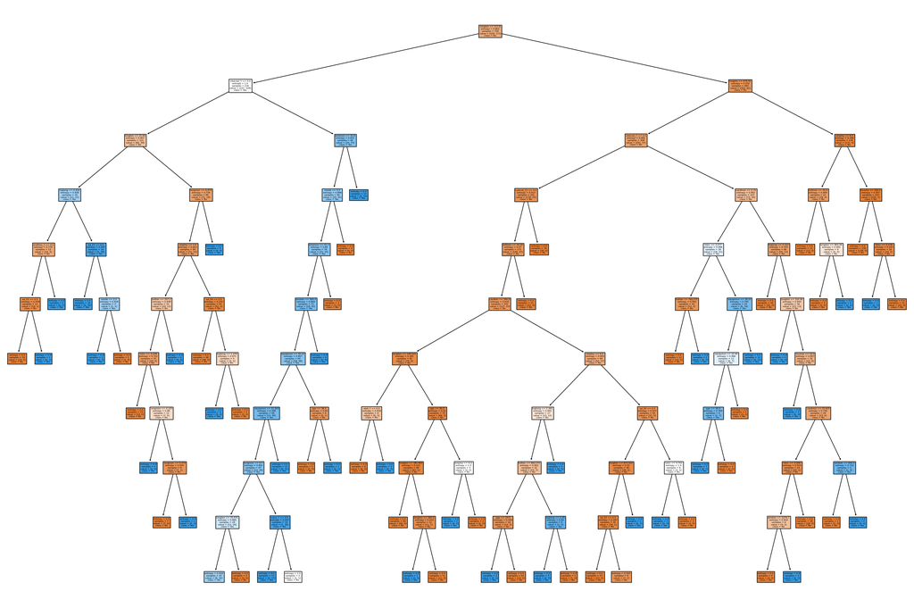

```python
fig = plt.figure(figsize=(30,20))
tree.plot_tree(model,
               feature_names=list(predictors_train_numeric.columns),
               class_names=['No', 'Yes'],
               filled=True)
```

# Results and Model Evaluation

The overall accuracy of the model is 87%, as seen with the results/classification report below. This is generally a good score and the aim was for it to be between 70-80%, but we must dig deeper to see if this model is worthy.  
Starting with class 0 (no churn), 89% of the customers predicted were actually correct, and 92% of the customers who actually did not churn were correctly identified (recall). This gives us a 0.91 (91%) f1-score which is very good.  
Now moving on to class 1 (churn), 80% of the customers predicted as "churn" were correct, and 72% of the actual churners were correctly identified. This gives us a f1-score of 0.76 which is not so good.  
The whole basis of this model was to identify churners, and with a recall of 72%, this means that 28% of actual churners were missed!

```python
prediction_on_test = model.predict(predictors_test_numeric)
```

[output not shown]

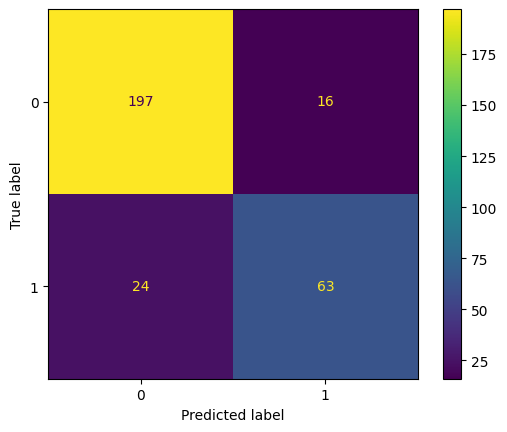

```python
cm = confusion_matrix(target_test_numeric, prediction_on_test)
ConfusionMatrixDisplay(confusion_matrix=cm, display_labels=model.classes_).plot()
```

```python
print(classification_report(target_test_numeric, prediction_on_test))
```

```
              precision    recall  f1-score   support

           0       0.89      0.92      0.91       213
           1       0.80      0.72      0.76        87

    accuracy                           0.87       300
   macro avg       0.84      0.82      0.83       300
weighted avg       0.86      0.87      0.86       300
```

# Conclusion

In this project, I was tasked to employ a decision tree classifier to predict customer churn within a telecommunications company. I began with researching what factors contribute to customer churn within the telecommunications industy. After preprocessing the data, I started to develop the decision tree model by partitioning the data into training and test sets. I used a maximum depth of 10.  
The model achieved an overall accuracy of 87%, which indicates it performs quite well. However, after analyzing deeper, the model's performance in identifiying churners was lacking. While the precision for churners was 80%, the recall was only 72%, meaing 28% of the actual churners were not identified by the model! This can have serious implications for businesses relying on the model to retain at-risk customers, since missed churners could leave without any retention effort.  
Strengths of my approach would include:

- The model's overall performance, especially identfiying non-churners. (for promotions, etc)
- The accuracy and precision for classifying customers as non-churners, which show the model can be trusted for a large portion of the customer base.

Weaknesses in my approach would include:

- The recall for churners is not as high as desired. The model missed 28% of actual churners, which limits its effectiveness for businesses.
- No balancing was used during this project which might have made the model much better.

While the model provides a foundation for predicting customer churn, I think businessess should be cautious when relying solely on this classifier. It's current strengths lie with identifying non-churners accurately, which is not the intended use of the model. The model was made to capture all at-risk customers, and it fails to do so 28% of the time.

```python
!jupyter nbconvert --to html "/content/drive/MyDrive/Colab Notebooks/melkumianrafael.ipynb"
```